# Optimal Treatment Analysis

## Outcome Variable

**Outcome Variable:** haz

## Predictor Variables

**Intervention Variable:** single

**Adjustment Set:**

- arm
- W_mage
- W_fage
- meducyrs
- feducyrs
- W_mhtcm
- W_mwtkg
- W_mbmi
- delta_W_mage
- delta_W_fage
- delta_meducyrs
- delta_feducyrs
- delta_W_mhtcm
- delta_W_mwtkg
- delta_W_mbmi

## Stratifying Variables

The analysis was stratified on these variable(s):

- agecat
- studyid
- country

## Data Summary

| agecat | studyid | country | single | n_cell | n |
| --- | --- | --- | --- | --- | --- |
| Birth | ki0047075b-MAL-ED | BANGLADESH | 0 | 257 | 257 |
| Birth | ki0047075b-MAL-ED | BANGLADESH | 1 | 0 | 257 |
| Birth | ki0047075b-MAL-ED | BRAZIL | 0 | 166 | 191 |
| Birth | ki0047075b-MAL-ED | BRAZIL | 1 | 25 | 191 |
| Birth | ki0047075b-MAL-ED | INDIA | 0 | 205 | 205 |
| Birth | ki0047075b-MAL-ED | INDIA | 1 | 0 | 205 |
| Birth | ki0047075b-MAL-ED | NEPAL | 0 | 173 | 173 |
| Birth | ki0047075b-MAL-ED | NEPAL | 1 | 0 | 173 |
| Birth | ki0047075b-MAL-ED | PERU | 0 | 253 | 287 |
| Birth | ki0047075b-MAL-ED | PERU | 1 | 34 | 287 |
| Birth | ki0047075b-MAL-ED | SOUTH AFRICA | 0 | 146 | 262 |
| Birth | ki0047075b-MAL-ED | SOUTH AFRICA | 1 | 116 | 262 |
| Birth | ki0047075b-MAL-ED | TANZANIA, UNITED REPUBLIC OF | 0 | 117 | 123 |
| Birth | ki0047075b-MAL-ED | TANZANIA, UNITED REPUBLIC OF | 1 | 6 | 123 |
| Birth | ki1119695-PROBIT | BELARUS | 0 | 13343 | 13884 |
| Birth | ki1119695-PROBIT | BELARUS | 1 | 541 | 13884 |
| Birth | ki1126311-ZVITAMBO | ZIMBABWE | 0 | 12902 | 13772 |
| Birth | ki1126311-ZVITAMBO | ZIMBABWE | 1 | 870 | 13772 |
| Birth | ki1135781-COHORTS | GUATEMALA | 0 | 719 | 767 |
| Birth | ki1135781-COHORTS | GUATEMALA | 1 | 48 | 767 |
| Birth | ki1135781-COHORTS | INDIA | 0 | 4771 | 4778 |
| Birth | ki1135781-COHORTS | INDIA | 1 | 7 | 4778 |
| Birth | ki1135781-COHORTS | PHILIPPINES | 0 | 2936 | 3010 |
| Birth | ki1135781-COHORTS | PHILIPPINES | 1 | 74 | 3010 |
| 6 months | ki0047075b-MAL-ED | BANGLADESH | 0 | 241 | 241 |
| 6 months | ki0047075b-MAL-ED | BANGLADESH | 1 | 0 | 241 |
| 6 months | ki0047075b-MAL-ED | BRAZIL | 0 | 179 | 209 |
| 6 months | ki0047075b-MAL-ED | BRAZIL | 1 | 30 | 209 |
| 6 months | ki0047075b-MAL-ED | INDIA | 0 | 234 | 234 |
| 6 months | ki0047075b-MAL-ED | INDIA | 1 | 0 | 234 |
| 6 months | ki0047075b-MAL-ED | NEPAL | 0 | 236 | 236 |
| 6 months | ki0047075b-MAL-ED | NEPAL | 1 | 0 | 236 |
| 6 months | ki0047075b-MAL-ED | PERU | 0 | 240 | 273 |
| 6 months | ki0047075b-MAL-ED | PERU | 1 | 33 | 273 |
| 6 months | ki0047075b-MAL-ED | SOUTH AFRICA | 0 | 140 | 254 |
| 6 months | ki0047075b-MAL-ED | SOUTH AFRICA | 1 | 114 | 254 |
| 6 months | ki0047075b-MAL-ED | TANZANIA, UNITED REPUBLIC OF | 0 | 239 | 247 |
| 6 months | ki0047075b-MAL-ED | TANZANIA, UNITED REPUBLIC OF | 1 | 8 | 247 |
| 6 months | ki1066203-TanzaniaChild2 | TANZANIA, UNITED REPUBLIC OF | 0 | 1835 | 2013 |
| 6 months | ki1066203-TanzaniaChild2 | TANZANIA, UNITED REPUBLIC OF | 1 | 178 | 2013 |
| 6 months | ki1112895-Guatemala BSC | GUATEMALA | 0 | 248 | 277 |
| 6 months | ki1112895-Guatemala BSC | GUATEMALA | 1 | 29 | 277 |
| 6 months | ki1119695-PROBIT | BELARUS | 0 | 15118 | 15761 |
| 6 months | ki1119695-PROBIT | BELARUS | 1 | 643 | 15761 |
| 6 months | ki1126311-ZVITAMBO | ZIMBABWE | 0 | 7775 | 8265 |
| 6 months | ki1126311-ZVITAMBO | ZIMBABWE | 1 | 490 | 8265 |
| 6 months | ki1135781-COHORTS | GUATEMALA | 0 | 826 | 893 |
| 6 months | ki1135781-COHORTS | GUATEMALA | 1 | 67 | 893 |
| 6 months | ki1135781-COHORTS | INDIA | 0 | 4962 | 4971 |
| 6 months | ki1135781-COHORTS | INDIA | 1 | 9 | 4971 |
| 6 months | ki1135781-COHORTS | PHILIPPINES | 0 | 2608 | 2676 |
| 6 months | ki1135781-COHORTS | PHILIPPINES | 1 | 68 | 2676 |
| 24 months | ki0047075b-MAL-ED | BANGLADESH | 0 | 212 | 212 |
| 24 months | ki0047075b-MAL-ED | BANGLADESH | 1 | 0 | 212 |
| 24 months | ki0047075b-MAL-ED | BRAZIL | 0 | 148 | 169 |
| 24 months | ki0047075b-MAL-ED | BRAZIL | 1 | 21 | 169 |
| 24 months | ki0047075b-MAL-ED | INDIA | 0 | 225 | 225 |
| 24 months | ki0047075b-MAL-ED | INDIA | 1 | 0 | 225 |
| 24 months | ki0047075b-MAL-ED | NEPAL | 0 | 228 | 228 |
| 24 months | ki0047075b-MAL-ED | NEPAL | 1 | 0 | 228 |
| 24 months | ki0047075b-MAL-ED | PERU | 0 | 176 | 201 |
| 24 months | ki0047075b-MAL-ED | PERU | 1 | 25 | 201 |
| 24 months | ki0047075b-MAL-ED | SOUTH AFRICA | 0 | 131 | 238 |
| 24 months | ki0047075b-MAL-ED | SOUTH AFRICA | 1 | 107 | 238 |
| 24 months | ki0047075b-MAL-ED | TANZANIA, UNITED REPUBLIC OF | 0 | 208 | 214 |
| 24 months | ki0047075b-MAL-ED | TANZANIA, UNITED REPUBLIC OF | 1 | 6 | 214 |
| 24 months | ki1066203-TanzaniaChild2 | TANZANIA, UNITED REPUBLIC OF | 0 | 6 | 6 |
| 24 months | ki1066203-TanzaniaChild2 | TANZANIA, UNITED REPUBLIC OF | 1 | 0 | 6 |
| 24 months | ki1119695-PROBIT | BELARUS | 0 | 3890 | 4035 |
| 24 months | ki1119695-PROBIT | BELARUS | 1 | 145 | 4035 |
| 24 months | ki1126311-ZVITAMBO | ZIMBABWE | 0 | 413 | 456 |
| 24 months | ki1126311-ZVITAMBO | ZIMBABWE | 1 | 43 | 456 |
| 24 months | ki1135781-COHORTS | GUATEMALA | 0 | 926 | 1013 |
| 24 months | ki1135781-COHORTS | GUATEMALA | 1 | 87 | 1013 |
| 24 months | ki1135781-COHORTS | INDIA | 0 | 3747 | 3756 |
| 24 months | ki1135781-COHORTS | INDIA | 1 | 9 | 3756 |
| 24 months | ki1135781-COHORTS | PHILIPPINES | 0 | 2357 | 2416 |
| 24 months | ki1135781-COHORTS | PHILIPPINES | 1 | 59 | 2416 |

The following strata were considered:

- agecat: 24 months, studyid: ki0047075b-MAL-ED, country: BANGLADESH
- agecat: 24 months, studyid: ki0047075b-MAL-ED, country: BRAZIL
- agecat: 24 months, studyid: ki0047075b-MAL-ED, country: INDIA
- agecat: 24 months, studyid: ki0047075b-MAL-ED, country: NEPAL
- agecat: 24 months, studyid: ki0047075b-MAL-ED, country: PERU
- agecat: 24 months, studyid: ki0047075b-MAL-ED, country: SOUTH AFRICA
- agecat: 24 months, studyid: ki0047075b-MAL-ED, country: TANZANIA, UNITED REPUBLIC OF
- agecat: 24 months, studyid: ki1066203-TanzaniaChild2, country: TANZANIA, UNITED REPUBLIC OF
- agecat: 24 months, studyid: ki1119695-PROBIT, country: BELARUS
- agecat: 24 months, studyid: ki1126311-ZVITAMBO, country: ZIMBABWE
- agecat: 24 months, studyid: ki1135781-COHORTS, country: GUATEMALA
- agecat: 24 months, studyid: ki1135781-COHORTS, country: INDIA
- agecat: 24 months, studyid: ki1135781-COHORTS, country: PHILIPPINES
- agecat: 6 months, studyid: ki0047075b-MAL-ED, country: BANGLADESH
- agecat: 6 months, studyid: ki0047075b-MAL-ED, country: BRAZIL
- agecat: 6 months, studyid: ki0047075b-MAL-ED, country: INDIA
- agecat: 6 months, studyid: ki0047075b-MAL-ED, country: NEPAL
- agecat: 6 months, studyid: ki0047075b-MAL-ED, country: PERU
- agecat: 6 months, studyid: ki0047075b-MAL-ED, country: SOUTH AFRICA
- agecat: 6 months, studyid: ki0047075b-MAL-ED, country: TANZANIA, UNITED REPUBLIC OF
- agecat: 6 months, studyid: ki1066203-TanzaniaChild2, country: TANZANIA, UNITED REPUBLIC OF
- agecat: 6 months, studyid: ki1112895-Guatemala BSC, country: GUATEMALA
- agecat: 6 months, studyid: ki1119695-PROBIT, country: BELARUS
- agecat: 6 months, studyid: ki1126311-ZVITAMBO, country: ZIMBABWE
- agecat: 6 months, studyid: ki1135781-COHORTS, country: GUATEMALA
- agecat: 6 months, studyid: ki1135781-COHORTS, country: INDIA
- agecat: 6 months, studyid: ki1135781-COHORTS, country: PHILIPPINES
- agecat: Birth, studyid: ki0047075b-MAL-ED, country: BANGLADESH
- agecat: Birth, studyid: ki0047075b-MAL-ED, country: BRAZIL
- agecat: Birth, studyid: ki0047075b-MAL-ED, country: INDIA
- agecat: Birth, studyid: ki0047075b-MAL-ED, country: NEPAL
- agecat: Birth, studyid: ki0047075b-MAL-ED, country: PERU
- agecat: Birth, studyid: ki0047075b-MAL-ED, country: SOUTH AFRICA
- agecat: Birth, studyid: ki0047075b-MAL-ED, country: TANZANIA, UNITED REPUBLIC OF
- agecat: Birth, studyid: ki1119695-PROBIT, country: BELARUS
- agecat: Birth, studyid: ki1126311-ZVITAMBO, country: ZIMBABWE
- agecat: Birth, studyid: ki1135781-COHORTS, country: GUATEMALA
- agecat: Birth, studyid: ki1135781-COHORTS, country: INDIA
- agecat: Birth, studyid: ki1135781-COHORTS, country: PHILIPPINES

### Dropped Strata

Some strata were dropped due to rare outcomes:

- agecat: Birth, studyid: ki0047075b-MAL-ED, country: BANGLADESH
- agecat: Birth, studyid: ki0047075b-MAL-ED, country: INDIA
- agecat: Birth, studyid: ki0047075b-MAL-ED, country: NEPAL
- agecat: 6 months, studyid: ki0047075b-MAL-ED, country: BANGLADESH
- agecat: 6 months, studyid: ki0047075b-MAL-ED, country: INDIA
- agecat: 6 months, studyid: ki0047075b-MAL-ED, country: NEPAL
- agecat: 24 months, studyid: ki0047075b-MAL-ED, country: BANGLADESH
- agecat: 24 months, studyid: ki0047075b-MAL-ED, country: INDIA
- agecat: 24 months, studyid: ki0047075b-MAL-ED, country: NEPAL
- agecat: 24 months, studyid: ki1066203-TanzaniaChild2, country: TANZANIA, UNITED REPUBLIC OF

## Methods Detail

We’re interested in the causal parameters $E[Y_a]$ for all values of $a \in \mathcal{A}$. These parameters represent the mean outcome if, possibly contrary to fact, we intervened to set all units to have $A=a$. Under the randomization and positivity assumptions, these are identified by the statistical parameters $\psi_a=E_W[E_{Y|A,W}(Y|A=a,W)]$. In addition, we’re interested in the mean of $Y$, $E[Y]$ under no intervention (the observed mean). We will estimate these parameters by using SuperLearner to fit the relevant likelihood factors – $E_{Y|A,W}(Y|A=a,W)$ and $p(A=a|W)$, and then updating our likelihood fit using a joint TMLE.

For unadjusted analyses ($W=\{\}$), initial likelihoods were estimated using Lrnr_glm to estimate the simple $E(Y|A)$ and Lrnr_mean to estimate $p(A)$. For adjusted analyses, a small library containing Lrnr_glmnet, Lrnr_xgboost, and Lrnr_mean was used.

Having estimated these parameters, we will then use the delta method to estimate relative risks and attributable risks relative to a prespecified baseline level of $A$.

# Results Detail

## Results Plots

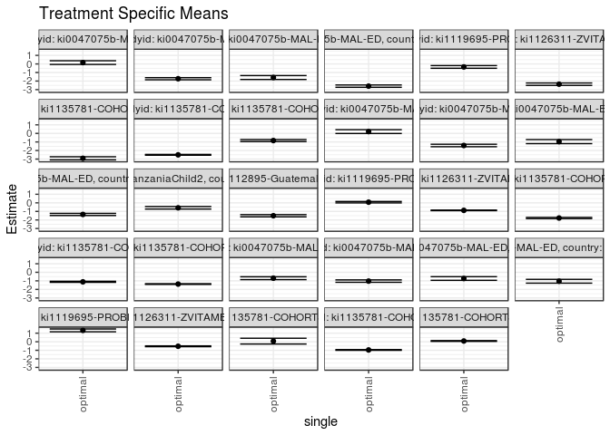

## Results Table

### Parameter: TSM

| agecat | studyid | country | intervention_level | baseline_level | estimate | ci_lower | ci_upper |
| --- | --- | --- | --- | --- | --- | --- | --- |
| Birth | ki0047075b-MAL-ED | BRAZIL | optimal | observed | -0.6898778 | -0.8565151 | -0.5232405 |
| Birth | ki0047075b-MAL-ED | PERU | optimal | observed | -1.0293254 | -1.1677167 | -0.8909341 |
| Birth | ki0047075b-MAL-ED | SOUTH AFRICA | optimal | observed | -0.7255185 | -0.9395322 | -0.5115048 |
| Birth | ki0047075b-MAL-ED | TANZANIA, UNITED REPUBLIC OF | optimal | observed | -1.0437438 | -1.2660944 | -0.8213933 |
| Birth | ki1119695-PROBIT | BELARUS | optimal | observed | 1.3271357 | 1.1616401 | 1.4926313 |
| Birth | ki1126311-ZVITAMBO | ZIMBABWE | optimal | observed | -0.5299188 | -0.5795039 | -0.4803338 |
| Birth | ki1135781-COHORTS | GUATEMALA | optimal | observed | 0.0700759 | -0.2668694 | 0.4070212 |
| Birth | ki1135781-COHORTS | INDIA | optimal | observed | -0.9592040 | -0.9997143 | -0.9186937 |
| Birth | ki1135781-COHORTS | PHILIPPINES | optimal | observed | 0.0862711 | 0.0394072 | 0.1331350 |
| 6 months | ki0047075b-MAL-ED | BRAZIL | optimal | observed | 0.2100929 | -0.0133284 | 0.4335142 |
| 6 months | ki0047075b-MAL-ED | PERU | optimal | observed | -1.4137114 | -1.5577225 | -1.2697004 |
| 6 months | ki0047075b-MAL-ED | SOUTH AFRICA | optimal | observed | -0.9613273 | -1.1969128 | -0.7257418 |
| 6 months | ki0047075b-MAL-ED | TANZANIA, UNITED REPUBLIC OF | optimal | observed | -1.3545793 | -1.4799412 | -1.2292175 |
| 6 months | ki1066203-TanzaniaChild2 | TANZANIA, UNITED REPUBLIC OF | optimal | observed | -0.5808386 | -0.7257604 | -0.4359169 |
| 6 months | ki1112895-Guatemala BSC | GUATEMALA | optimal | observed | -1.5055634 | -1.6354629 | -1.3756639 |
| 6 months | ki1119695-PROBIT | BELARUS | optimal | observed | 0.0782103 | -0.0056219 | 0.1620425 |
| 6 months | ki1126311-ZVITAMBO | ZIMBABWE | optimal | observed | -0.8797262 | -0.9068774 | -0.8525750 |
| 6 months | ki1135781-COHORTS | GUATEMALA | optimal | observed | -1.7724865 | -1.8449710 | -1.7000019 |
| 6 months | ki1135781-COHORTS | INDIA | optimal | observed | -1.1159310 | -1.1779796 | -1.0538824 |
| 6 months | ki1135781-COHORTS | PHILIPPINES | optimal | observed | -1.3772252 | -1.4185534 | -1.3358970 |
| 24 months | ki0047075b-MAL-ED | BRAZIL | optimal | observed | 0.1581419 | -0.0563253 | 0.3726091 |
| 24 months | ki0047075b-MAL-ED | PERU | optimal | observed | -1.7270529 | -1.8513311 | -1.6027747 |
| 24 months | ki0047075b-MAL-ED | SOUTH AFRICA | optimal | observed | -1.5849601 | -1.8125826 | -1.3573377 |
| 24 months | ki0047075b-MAL-ED | TANZANIA, UNITED REPUBLIC OF | optimal | observed | -2.5926074 | -2.7295880 | -2.4556268 |
| 24 months | ki1119695-PROBIT | BELARUS | optimal | observed | -0.3480792 | -0.5045233 | -0.1916351 |
| 24 months | ki1126311-ZVITAMBO | ZIMBABWE | optimal | observed | -2.3645959 | -2.5064645 | -2.2227273 |
| 24 months | ki1135781-COHORTS | GUATEMALA | optimal | observed | -2.9124109 | -3.0932981 | -2.7315238 |
| 24 months | ki1135781-COHORTS | INDIA | optimal | observed | -2.5056794 | -2.5541539 | -2.4572049 |
| 24 months | ki1135781-COHORTS | PHILIPPINES | optimal | observed | -0.8362606 | -0.9545384 | -0.7179827 |

### Parameter: E(Y)

| agecat | studyid | country | intervention_level | baseline_level | estimate | ci_lower | ci_upper |
| --- | --- | --- | --- | --- | --- | --- | --- |
| Birth | ki0047075b-MAL-ED | BRAZIL | observed | observed | -0.7609424 | -0.9178311 | -0.6040538 |
| Birth | ki0047075b-MAL-ED | PERU | observed | observed | -0.9322300 | -1.0461262 | -0.8183337 |
| Birth | ki0047075b-MAL-ED | SOUTH AFRICA | observed | observed | -0.7266031 | -0.8549719 | -0.5982342 |
| Birth | ki0047075b-MAL-ED | TANZANIA, UNITED REPUBLIC OF | observed | observed | -0.9338211 | -1.1465079 | -0.7211344 |
| Birth | ki1119695-PROBIT | BELARUS | observed | observed | 1.3254775 | 1.1669293 | 1.4840258 |
| Birth | ki1126311-ZVITAMBO | ZIMBABWE | observed | observed | -0.5014820 | -0.5220753 | -0.4808887 |
| Birth | ki1135781-COHORTS | GUATEMALA | observed | observed | 0.1511213 | 0.0632481 | 0.2389944 |
| Birth | ki1135781-COHORTS | INDIA | observed | observed | -0.6774424 | -0.7103357 | -0.6445492 |
| Birth | ki1135781-COHORTS | PHILIPPINES | observed | observed | -0.2465548 | -0.2856502 | -0.2074594 |
| 6 months | ki0047075b-MAL-ED | BRAZIL | observed | observed | 0.0510207 | -0.0930194 | 0.1950608 |
| 6 months | ki0047075b-MAL-ED | PERU | observed | observed | -1.3268010 | -1.4351217 | -1.2184802 |
| 6 months | ki0047075b-MAL-ED | SOUTH AFRICA | observed | observed | -1.0633760 | -1.1911088 | -0.9356432 |
| 6 months | ki0047075b-MAL-ED | TANZANIA, UNITED REPUBLIC OF | observed | observed | -1.3601215 | -1.4821830 | -1.2380600 |
| 6 months | ki1066203-TanzaniaChild2 | TANZANIA, UNITED REPUBLIC OF | observed | observed | -0.5457721 | -0.5948454 | -0.4966988 |
| 6 months | ki1112895-Guatemala BSC | GUATEMALA | observed | observed | -1.5624368 | -1.6783540 | -1.4465196 |
| 6 months | ki1119695-PROBIT | BELARUS | observed | observed | 0.1069986 | 0.0122286 | 0.2017686 |
| 6 months | ki1126311-ZVITAMBO | ZIMBABWE | observed | observed | -0.8906213 | -0.9166407 | -0.8646018 |
| 6 months | ki1135781-COHORTS | GUATEMALA | observed | observed | -1.8089474 | -1.8800645 | -1.7378303 |
| 6 months | ki1135781-COHORTS | INDIA | observed | observed | -1.0418789 | -1.0745363 | -1.0092215 |
| 6 months | ki1135781-COHORTS | PHILIPPINES | observed | observed | -1.1414425 | -1.1836656 | -1.0992193 |
| 24 months | ki0047075b-MAL-ED | BRAZIL | observed | observed | 0.0418343 | -0.1253834 | 0.2090521 |
| 24 months | ki0047075b-MAL-ED | PERU | observed | observed | -1.7500995 | -1.8705474 | -1.6296516 |
| 24 months | ki0047075b-MAL-ED | SOUTH AFRICA | observed | observed | -1.6228361 | -1.7581177 | -1.4875546 |
| 24 months | ki0047075b-MAL-ED | TANZANIA, UNITED REPUBLIC OF | observed | observed | -2.6058879 | -2.7403043 | -2.4714714 |
| 24 months | ki1119695-PROBIT | BELARUS | observed | observed | -0.1314048 | -0.4282725 | 0.1654630 |
| 24 months | ki1126311-ZVITAMBO | ZIMBABWE | observed | observed | -2.3925000 | -2.5069364 | -2.2780636 |
| 24 months | ki1135781-COHORTS | GUATEMALA | observed | observed | -2.8644028 | -2.9307312 | -2.7980743 |
| 24 months | ki1135781-COHORTS | INDIA | observed | observed | -2.0008573 | -2.0401168 | -1.9615978 |
| 24 months | ki1135781-COHORTS | PHILIPPINES | observed | observed | -2.3962210 | -2.4413335 | -2.3511085 |

### Parameter: PAR

| agecat | studyid | country | intervention_level | baseline_level | estimate | ci_lower | ci_upper |
| --- | --- | --- | --- | --- | --- | --- | --- |
| Birth | ki0047075b-MAL-ED | BRAZIL | optimal | observed | -0.0710646 | -0.1375869 | -0.0045422 |
| Birth | ki0047075b-MAL-ED | PERU | optimal | observed | 0.0970954 | -0.0113935 | 0.2055844 |
| Birth | ki0047075b-MAL-ED | SOUTH AFRICA | optimal | observed | -0.0010845 | -0.1790577 | 0.1768886 |
| Birth | ki0047075b-MAL-ED | TANZANIA, UNITED REPUBLIC OF | optimal | observed | 0.1099227 | 0.0185395 | 0.2013059 |
| Birth | ki1119695-PROBIT | BELARUS | optimal | observed | -0.0016582 | -0.0174565 | 0.0141401 |
| Birth | ki1126311-ZVITAMBO | ZIMBABWE | optimal | observed | 0.0284369 | -0.0167104 | 0.0735841 |
| Birth | ki1135781-COHORTS | GUATEMALA | optimal | observed | 0.0810453 | -0.2396084 | 0.4016991 |
| Birth | ki1135781-COHORTS | INDIA | optimal | observed | 0.2817615 | 0.2324994 | 0.3310236 |
| Birth | ki1135781-COHORTS | PHILIPPINES | optimal | observed | -0.3328259 | -0.3801040 | -0.2855478 |
| 6 months | ki0047075b-MAL-ED | BRAZIL | optimal | observed | -0.1590722 | -0.3552770 | 0.0371327 |
| 6 months | ki0047075b-MAL-ED | PERU | optimal | observed | 0.0869105 | -0.0153250 | 0.1891459 |
| 6 months | ki0047075b-MAL-ED | SOUTH AFRICA | optimal | observed | -0.1020487 | -0.3061729 | 0.1020755 |
| 6 months | ki0047075b-MAL-ED | TANZANIA, UNITED REPUBLIC OF | optimal | observed | -0.0055421 | -0.0197485 | 0.0086643 |
| 6 months | ki1066203-TanzaniaChild2 | TANZANIA, UNITED REPUBLIC OF | optimal | observed | 0.0350666 | -0.1038525 | 0.1739857 |
| 6 months | ki1112895-Guatemala BSC | GUATEMALA | optimal | observed | -0.0568734 | -0.1243722 | 0.0106255 |
| 6 months | ki1119695-PROBIT | BELARUS | optimal | observed | 0.0287883 | -0.0397432 | 0.0973197 |
| 6 months | ki1126311-ZVITAMBO | ZIMBABWE | optimal | observed | -0.0108951 | -0.0198694 | -0.0019207 |
| 6 months | ki1135781-COHORTS | GUATEMALA | optimal | observed | -0.0364609 | -0.0606538 | -0.0122680 |
| 6 months | ki1135781-COHORTS | INDIA | optimal | observed | 0.0740521 | 0.0066698 | 0.1414344 |
| 6 months | ki1135781-COHORTS | PHILIPPINES | optimal | observed | 0.2357828 | 0.1862681 | 0.2852974 |
| 24 months | ki0047075b-MAL-ED | BRAZIL | optimal | observed | -0.1163076 | -0.2960622 | 0.0634471 |
| 24 months | ki0047075b-MAL-ED | PERU | optimal | observed | -0.0230466 | -0.0741452 | 0.0280521 |
| 24 months | ki0047075b-MAL-ED | SOUTH AFRICA | optimal | observed | -0.0378760 | -0.2303239 | 0.1545719 |
| 24 months | ki0047075b-MAL-ED | TANZANIA, UNITED REPUBLIC OF | optimal | observed | -0.0132805 | -0.0334694 | 0.0069084 |
| 24 months | ki1119695-PROBIT | BELARUS | optimal | observed | 0.2166744 | -0.0669322 | 0.5002810 |
| 24 months | ki1126311-ZVITAMBO | ZIMBABWE | optimal | observed | -0.0279041 | -0.1043322 | 0.0485240 |
| 24 months | ki1135781-COHORTS | GUATEMALA | optimal | observed | 0.0480082 | -0.1214113 | 0.2174277 |
| 24 months | ki1135781-COHORTS | INDIA | optimal | observed | 0.5048221 | 0.4479215 | 0.5617227 |
| 24 months | ki1135781-COHORTS | PHILIPPINES | optimal | observed | -1.5599604 | -1.6831002 | -1.4368207 |